# Time Series Analysis

Reg no : 19BCE1278

Name : Anish Sarkar

Date : 03/03/2022

# Time Series Analyis

```r
library(jsonlite)
library(dplyr)
data <- fromJSON("https://raw.githubusercontent.com/datameet/covid19/master/data/all_totals.json", flatten = TRUE)
```

```r
key_list <-data$row$key
# glimpse(data)
n <- length(unlist(key_list))

v <- c(1:n)
# v[v%%8 == 1]

dates <- unlist(key_list)[v[v%%8 == 1]]
length(dates)
```

```
## [1] 787
```

```r
date <- unlist(data$rows$key)
data_csv <- data.frame(
  day_num = c(1: length(dates)),
  date = as.Date(unique(dates))
)

head(data_csv)
```

```
##   day_num       date
## 1       1 2020-01-30
## 2       2 2020-02-02
## 3       3 2020-02-03
## 4       4 2020-03-02
## 5       5 2020-03-03
## 6       6 2020-03-10
```

# Time Series Exercise Problem :

Consider the COVID-19 pandemic situation. Analysis and forecast the pandemic trend by using Covid19 dataset :

1. You want to predict the last year monthly, weekly trend based on the RTPCR response, (i.e.) No. of +Ve cases and No. –Ve cases along with admitted and discharged trend.
2. Identify the death rate due to Covid-19.
3. Compare the last year and this year trends with respect to 1st , 2nd and 3rd wave also forecast the 4th Wave impact in India.
4. Construct the model using the Simple moving average, Exponential Moving Average and ARIMA to forecast the Covid19 Dataset.
5. Show the all above implementation with the visual impact.

```r
n <- length(key_list)
v1 <- c(1:n)
# data$rows$value[v1[v1%%4 == 1]]
data_csv$active_cases <- data$rows$value[v1[v1%%4 == 1]]
data_csv$cured <- data$rows$value[v1[v1%%4 == 2]]
data_csv$death <- data$rows$value[v1[v1%%4 == 3]]
data_csv$total_confirmed_cases <- data$rows$value[v1[v1%%4 == 0]]

tail(data_csv)
```

```
##     day_num       date active_cases    cured  death total_confirmed_cases
## 782     782 2022-02-24       148359 42219896 512924              42881179
## 783     783 2022-02-25       134235 42246884 513226              42894345
## 784     784 2022-02-26       121881 42270482 513481              42905844
## 785     785 2022-02-27       111472 42290921 513724              42916117
## 786     786 2022-02-28       102601 42307686 513843              42924130
## 787     787 2022-03-01        92472 42324550 514023              42931045
```

```r
nrow(data_csv)
```

```
## [1] 787
```

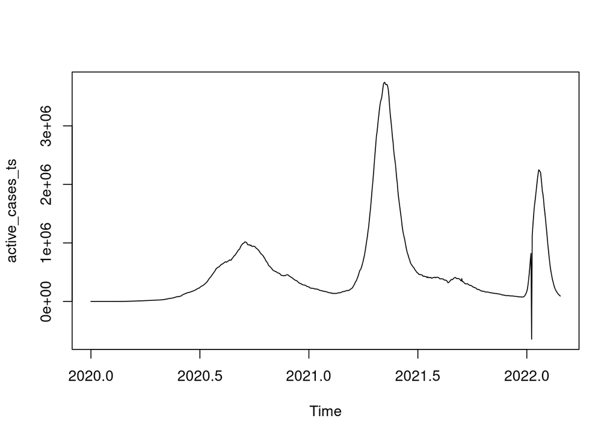

```r
# active_cases_ts <- ts(data = data_csv$active_cases, frequency = 12, start=data_csv$date[1])
active_cases_ts <- ts(data = data_csv$active_cases, start = c(2020,1,1), frequency = 365)
plot.ts(active_cases_ts)
```

1. You want to predict the last year monthly, weekly trend based on the RTPCR response, (i.e.) No. of +Ve cases and No. –Ve cases along with admitted and discharged trend.

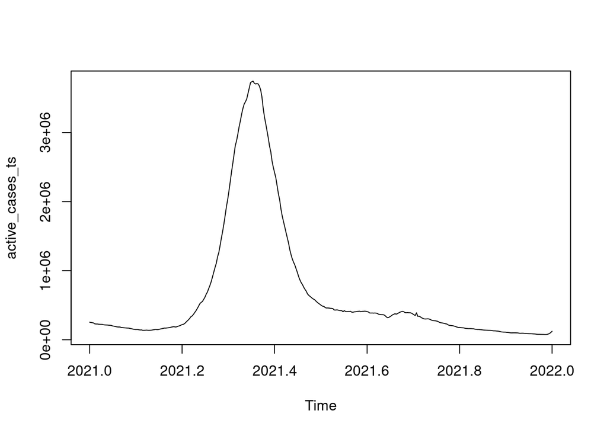

```r
start <- data_csv$day_num[data_csv$date == as.Date("2021-01-01")]
end <- data_csv$day_num[data_csv$date == as.Date("2022-01-01")]
active_cases_ts <- ts(data = data_csv$active_cases[c(start:nrow(data_csv))], start = c(2021,1,1), end = c(2022, 1, 1), frequency = 365)
# active_cases_ts <- ts(data = data_csv$active_cases)
# active_cases_ts
plot.ts(active_cases_ts)
```

2. Identify the death rate due to Covid-19

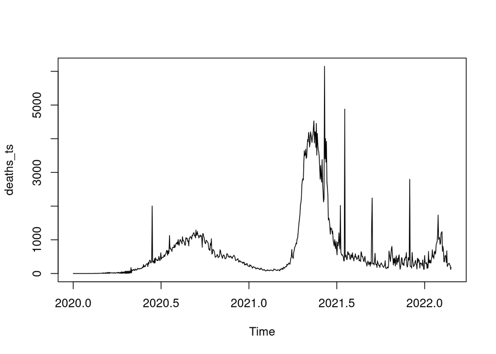

```r
death <- abs(data_csv$death[c(2: nrow(data_csv))] - data_csv$death[c(1: (nrow(data_csv) - 1))])

deaths_ts <- ts(data = death, start = c(2020,1,30), frequency = 365)
plot.ts(deaths_ts)
```

### Death Rate

```r
data_csv$death[nrow(data_csv)]/data_csv$total_confirmed_cases[nrow(data_csv)]
```

```
## [1] 0.01197322
```

### Death rate due to covid 19 in India is about 0.012.

3. Compare the last year and this year trends with respect to 1st , 2nd and 3rd wave also forecast the 4th Wave impact in India

```r
active_cases_ts <- ts(data = data_csv$active_cases, start = c(2020, 1, 30), frequency = 365)
forecast_covid_19 <- forecast::forecast(active_cases_ts, h=365)
```

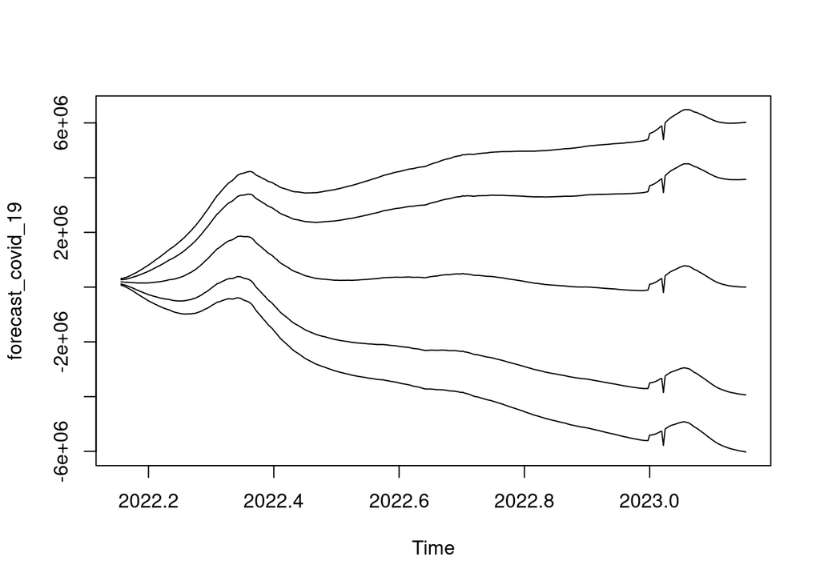

```r
plot.ts(forecast_covid_19)
```

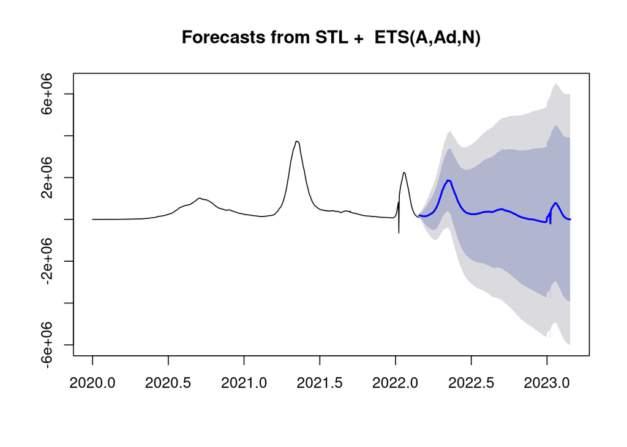

```r
plot(forecast_covid_19)
```

## According to this forecast the fourth wave of covid 19 may come between April and June of 2022.

4. Construct the model using the Simple moving average, Exponential Moving Average and ARIMA to forecast the Covid19 Dataset.

## Simple Moving Average

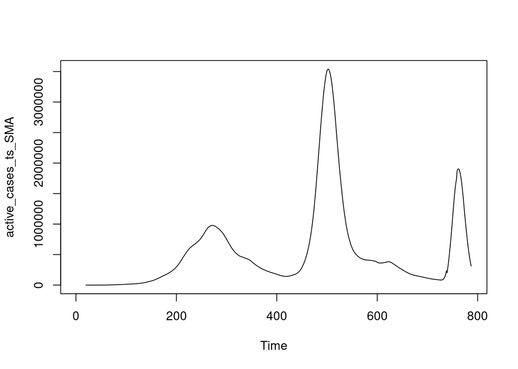

```r
library(TTR)
active_cases_ts_SMA <- SMA(active_cases_ts, n = 20)
plot.ts(active_cases_ts_SMA)
```

## Exponential Moving Average

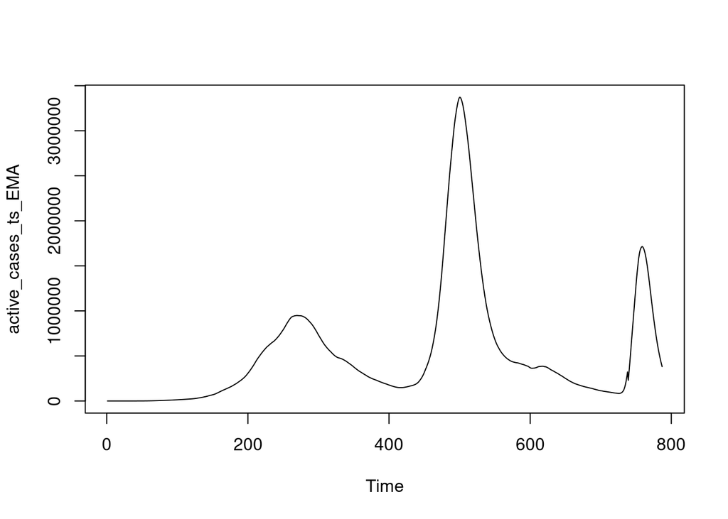

```r
library(pracma)
active_cases_ts_EMA = movavg(active_cases_ts, n = 20, type = "e")
plot.ts(active_cases_ts_EMA)
```

## ARIMA model

```r
# active_cases_ts <- ts(data = data_csv$active_cases, start = c(2020,1,30), frequency = 365)
active_cases_ts_log = log(active_cases_ts)
```

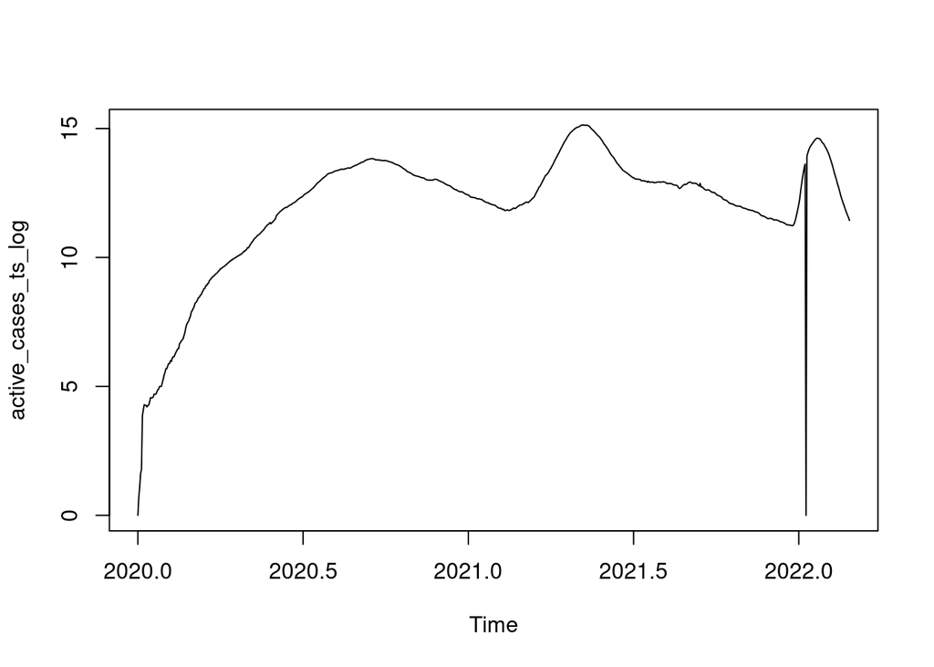

```r
active_cases_ts_log[active_cases_ts_log == 'NaN'] = 0
plot.ts(active_cases_ts_log)
```

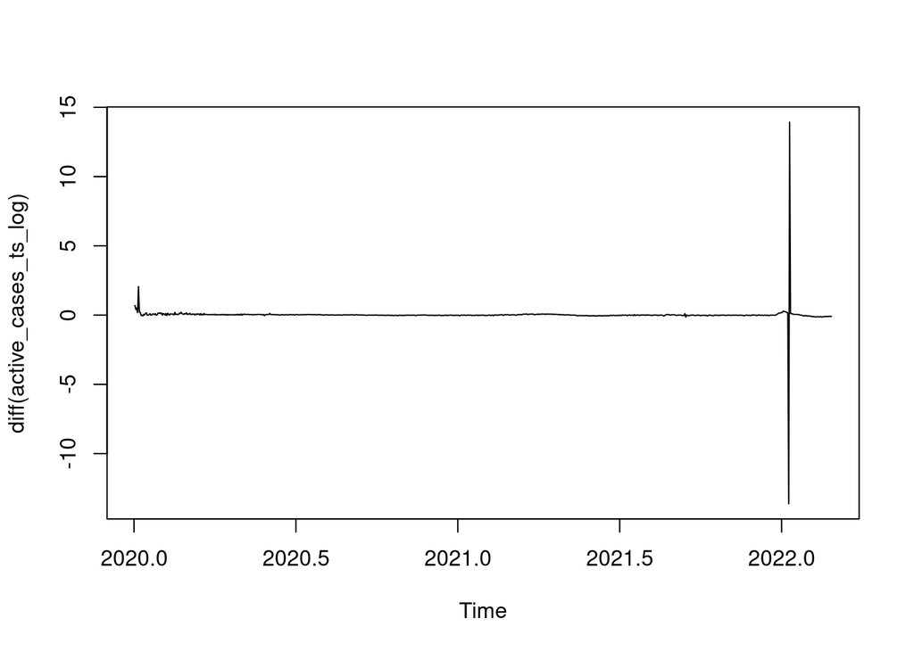

```r
plot.ts(diff(active_cases_ts_log))
```

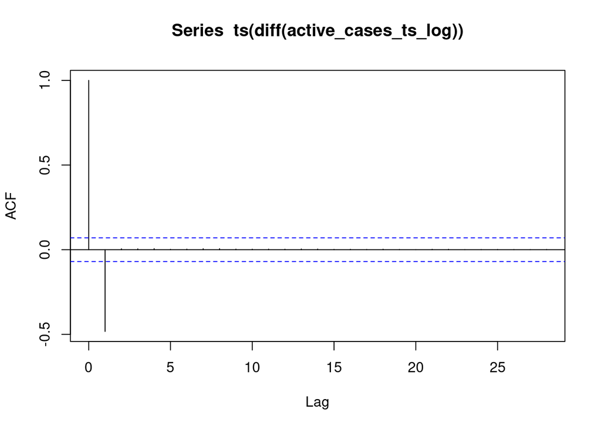

```r
# active_cases_ts_log
acf(ts(diff(active_cases_ts_log)))
```

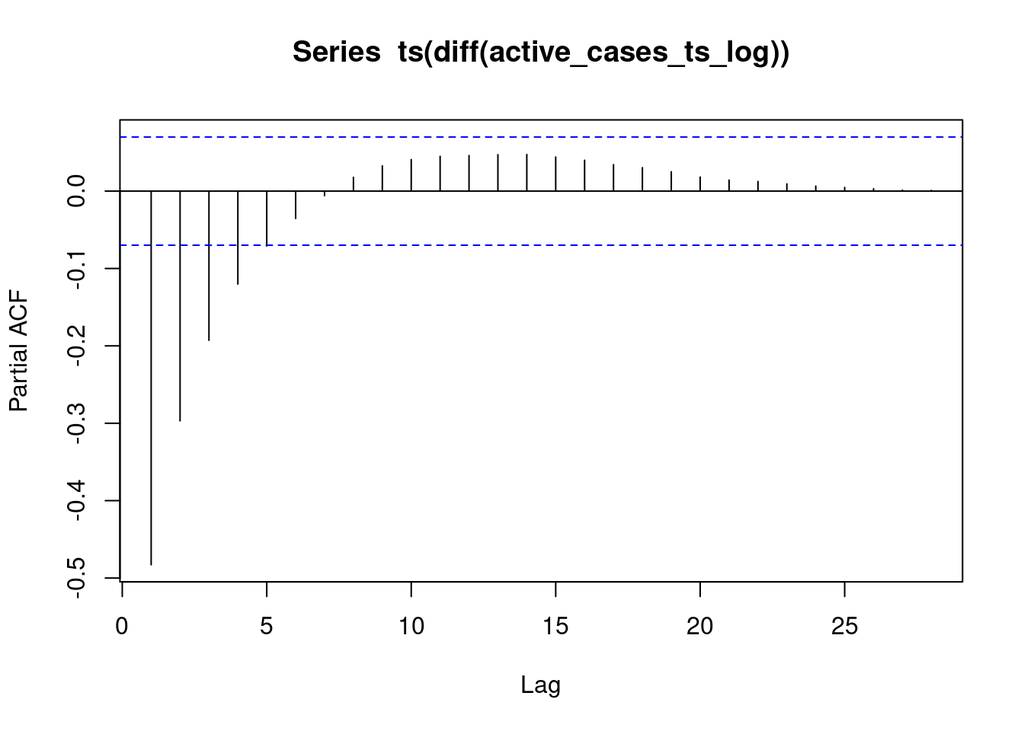

```r
pacf(ts(diff(active_cases_ts_log)))
```

### p=0, q=1 and d=1 (differenciating once) for ARIMA(p,d,q) -> therefore order of arima = (0,1,1)

```r
(fit <- arima(active_cases_ts_log, c(0, 1, 1), seasonal = list(order = c(0, 1, 1), period = 100)))
```

```
##
## Call:
## arima(x = active_cases_ts_log, order = c(0, 1, 1), seasonal = list(order = c(0,
##     1, 1), period = 100))
##
## Coefficients:
##           ma1     sma1
##       -0.6787  -0.0729
## s.e.   0.0252   0.0917
##
## sigma^2 estimated as 0.3748:  log likelihood = -641.39,  aic = 1288.79
```

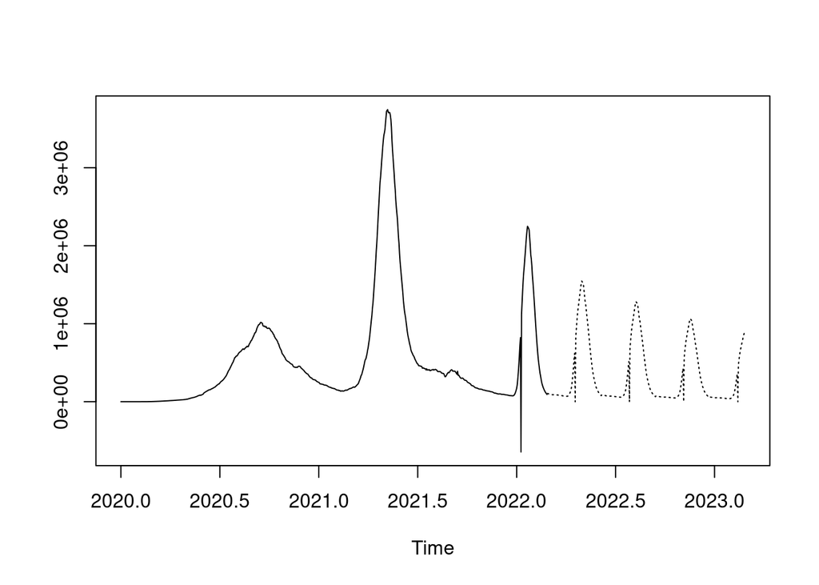

```r
pred <- predict(fit, n.ahead = 365)
ts.plot(active_cases_ts,2.718^pred$pred, lty = c(1,3))
```